# HUC8 stream gage/Pekel data comparison

### Overview

This document describes leveraging the correlation between monthly stream gage discharge data (ft<sup>3</sup>/s) and Pekel monthly surface water data in order to fill gaps in the Pekel data record.

Stream gage information is from **HUC8 18040008 Upper Merced** (https://waterdata.usgs.gov/nwis/). Volume streamflow discharge data from all gages with complete records from 2006 through 2015 (3 of 22 listed gages) were output to individual *.csv files and merged with Pekel data. The consolidated file is accessed on Google drive through its URL:

```r
data_url = "1M6P5RJqgTxdazxjJMakKU6qdrBeLwvYr" #1t6XaZANrVRMShni8Xo_0Ok7esSM2vqBt"
df <- read.csv(sprintf("https://docs.google.com/uc?id=%s&export=download", data_url))
```

Plotting individual stream gage data together with Pekel data yields the following. Pekel data are in areal units, but have been scaled for display purposes.

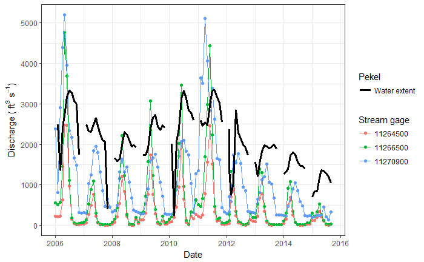

Pekel peak values appear to slightly lag stream gage peaks, so summarize correlations by non-lagged and 1-month lagged dates.  
Non-lagged correlations

| gage | COR |
| --- | --- |
| sg_11264500 | 0.3265814 |
| sg_11266500 | 0.2861194 |
| sg_11270900 | 0.5755734 |

1-month lagged correlations

| gage | COR |
| --- | --- |
| sg_11264500 | 0.5432250 |
| sg_11266500 | 0.5208475 |
| sg_11270900 | 0.7004832 |

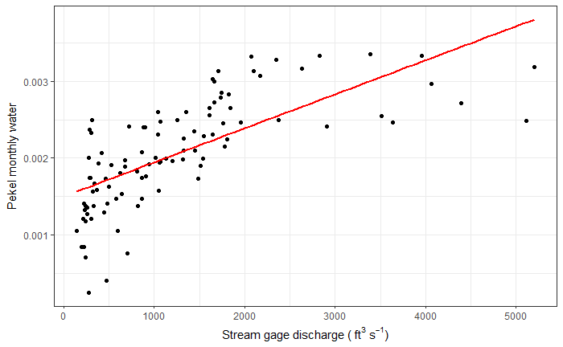

The best correlation (sg_11270900) is relatively linear until ~2900 ft<sup>3</sup>/s. Restricting the stream gage data range to that value yields a higher correlation:

```
[1] 0.7879936
```

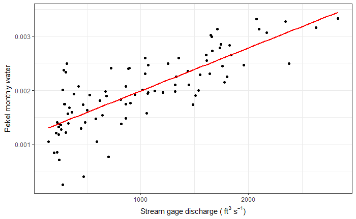

Calculate the linear equation of the fit

```
Call:
lm(formula = lag.water ~ sg_11270900, data = x.sub)

Residuals:
       Min         1Q     Median         3Q        Max
-1.165e-03 -2.015e-04 -9.320e-06  2.645e-04  1.061e-03

Coefficients:
             Estimate Std. Error t value Pr(>|t|)
(Intercept) 1.188e-03  8.019e-05   14.81   <2e-16 ***
sg_11270900 7.985e-07  6.651e-08   12.01   <2e-16 ***
---
Signif. codes:  0 ‘***’ 0.001 ‘**’ 0.01 ‘*’ 0.05 ‘.’ 0.1 ‘ ’ 1

Residual standard error: 0.0004182 on 88 degrees of freedom
  (19 observations deleted due to missingness)
Multiple R-squared:  0.6209,    Adjusted R-squared:  0.6166
F-statistic: 144.1 on 1 and 88 DF,  p-value: < 2.2e-16
```

and replace missing Pekel data water values with the resulting equation

$y = 0.0011877 + 7.9854662\times 10^{-7}x_i$

where x = stream gage value. The resulting plot shows how the estimated data fill gaps in the Pekel record:

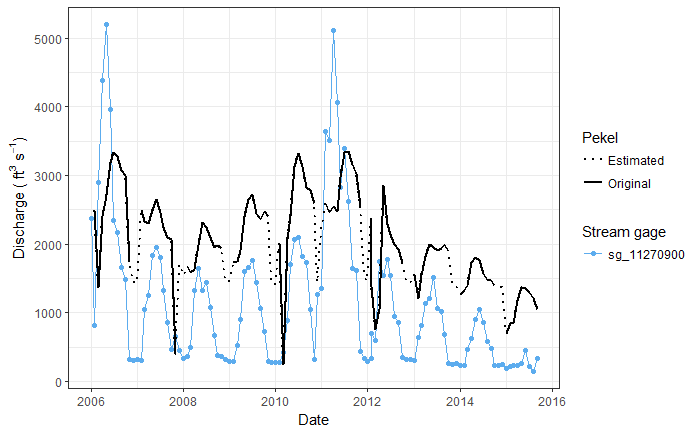